# Timesheet Analysis

## Turning the CSV Files into Dataframes for Analysis

### Step 1.1: Open and Read the Project Pulse CSV

```python
# Import pandas
import pandas as pd

# Read the CSV file
pp_df = pd.read_csv('./data/project_pulse_tracker.csv')

# Display the output
display(pp_df.head())
```

|  | STAGE | STARTED AT | ENDED AT | DURATION (H) | COST ($) | REMARKS |
| --- | --- | --- | --- | --- | --- | --- |
| 0 | Analysis | 01-01-1970, 12:00AM | 45752.79167 | 0.500000 | 13.000000 | Planning |
| 1 | Analysis | 01-01-1970, 12:00AM | 45752.98403 | 0.066667 | 1.733333 | Setup environment |
| 2 | Implementation | 01-01-1970, 12:00AM | 45753.35139 | 0.933333 | 24.266667 | Setup project |
| 3 | Implementation | 01-01-1970, 12:00AM | 45753.41667 | 1.566667 | 40.733333 | Add roles to User module |
| 4 | Implementation | 01-01-1970, 12:00AM | 45753.48333 | 0.883333 | 22.966667 | Backend of Project module completed |

### Step 1.2: Open and Read the Praise Story CSV

```python
# Import pandas
import pandas as pd

# Read the CSV file
ps_df = pd.read_csv('./data/praise_story_tracker.csv')

# Display the output
display(ps_df.head())
```

|  | STAGE | STARTED AT | ENDED AT | DURATION (H) | COST ($) | REMARKS |
| --- | --- | --- | --- | --- | --- | --- |
| 0 | Analysis | 45783.85278 | 45783.87500 | 0.533333 | 13.866667 | Logo |
| 1 | Analysis | 45784.49097 | 45784.51736 | 0.633333 | 16.466667 | Screen Plan |
| 2 | Analysis | 45784.51736 | 45784.52292 | 0.133333 | 3.466667 | Project Plan |
| 3 | Implementation | 45789.42361 | 45789.47569 | 1.250000 | 32.500000 | Testimony migration/Status helper |
| 4 | Implementation | 45789.82292 | 45789.91944 | 2.316667 | 60.233333 | Testimony backend module |

## Used GenAI to Perform Analyses

**Prompt**: given these 2 csv files, what kind of analyses can I perform on them?

Also uploaded the 2 CSVs to ChatGPT

### Response

The two CSV files — `praise_story_tracker.csv` and `project_pulse_tracker.csv` — contain similar structures, tracking the progress of tasks across different stages of two projects. Each file includes:

- `STAGE`: Project stage (e.g., Analysis, Implementation)
- `STARTED AT` and `ENDED AT`: Timestamps (Excel date format)
- `DURATION (H)`: Duration in hours
- `COST ($)`: Cost associated with the task
- `REMARKS`: Descriptive notes

### Here are several analyses you can perform on these datasets:

#### 1. **Time & Cost Summary**

- Total hours and total cost per project.
- Average hourly rate per stage.

```python
# Import pandas library
import pandas as pd

# Get the total cost of the 2 dfs
total_cost_pp = pp_df['COST ($)'].sum()
total_cost_ps = ps_df['COST ($)'].sum()

# Get the total duration of the 2 dfs
total_duration_pp = pp_df['DURATION (H)'].sum()
total_duration_ps = ps_df['DURATION (H)'].sum()

# Transform the total cost and durations into a df
data = {
    "Project Pulse": {
        "Total Cost ($)": total_cost_pp,
        "Total Duration (H)": total_duration_pp,
    },
    "Praise Story": {
        "Total Cost ($)": total_cost_ps,
        "Total Duration (H)": total_duration_ps,
    }
}

print('-- Summary --')
summary_df = pd.DataFrame(data).T
summary_df
```

```
-- Summary --
```

|  | Total Cost ($) | Total Duration (H) |
| --- | --- | --- |
| Project Pulse | 2259.833333 | 86.916667 |
| Praise Story | 1620.666667 | 62.333333 |

```python
# Import pandas
import pandas as pd

# Get average hourly rate per stage
pp_df['Hourly Rate'] = pp_df['COST ($)'] / pp_df['DURATION (H)']
ps_df['Hourly Rate'] = ps_df['COST ($)'] / ps_df['DURATION (H)']

# Group by Stage and Calculate the Average
avg1 = pp_df.groupby('STAGE')['Hourly Rate'].mean().rename('Project 1')
avg2 = ps_df.groupby('STAGE')['Hourly Rate'].mean().rename('Project 2')

comparison_df = pd.concat([avg1, avg2], axis=1)
print('-- Average Hourly Rate --')
display(comparison_df)
```

```
-- Average Hourly Rate --
```

| STAGE | Project 1 | Project 2 |
| --- | --- | --- |
| Analysis | 26.0 | 26.0 |
| Implementation | 26.0 | 26.0 |
| Testing | 26.0 | 26.0 |
| Design | NaN | 26.0 |

#### 2. **Stage Analysis**

- Total time and cost spent on each stage (e.g., Analysis vs. Implementation).
- Compare how much time and money each project allocates to each stage.

```python
# Import libraries
import pandas as pd

# Step 1: Group by Stage
# For Praise Story
praise_stage_summary = ps_df.groupby('STAGE')[['DURATION (H)', 'COST ($)']].sum().rename(
    columns={'DURATION (H)': 'Total Hours (Praise)', 'COST ($)': 'Total Cost (Praise)'})

# For Project Pulse
project_stage_summary = pp_df.groupby('STAGE')[['DURATION (H)', 'COST ($)']].sum().rename(
    columns={'DURATION (H)': 'Total Hours (Pulse)', 'COST ($)': 'Total Cost (Pulse)'})

# Step 2: Combine Results for Comparison
stage_comparison = pd.concat([praise_stage_summary, project_stage_summary], axis=1)
display(stage_comparison)
```

| STAGE | Total Hours (Praise) | Total Cost (Praise) | Total Hours (Pulse) | Total Cost (Pulse) |
| --- | --- | --- | --- | --- |
| Analysis | 1.300000 | 33.800000 | 0.566667 | 14.733333 |
| Design | 6.650000 | 172.900000 | NaN | NaN |
| Implementation | 50.100000 | 1302.600000 | 72.133333 | 1875.466667 |
| Testing | 4.283333 | 111.366667 | 14.216667 | 369.633333 |

#### 3. **Trend Analysis**

- Plot cumulative cost and time over tasks to see workflow intensity or burnout risk.
- Identify peaks in workload or cost.

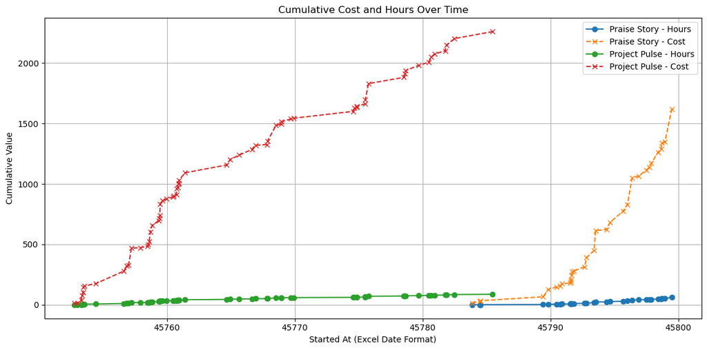

```python
# Import necessary libraries
import matplotlib.pyplot as plt

# Prepare cumulative data
praise_story_df_sorted = ps_df.sort_values(by='STARTED AT').copy()
praise_story_df_sorted['Cumulative Hours'] = praise_story_df_sorted['DURATION (H)'].cumsum()
praise_story_df_sorted['Cumulative Cost'] = praise_story_df_sorted['COST ($)'].cumsum()

project_pulse_df_sorted = pp_df.sort_values(by='STARTED AT').copy()
project_pulse_df_sorted['Cumulative Hours'] = project_pulse_df_sorted['DURATION (H)'].cumsum()
project_pulse_df_sorted['Cumulative Cost'] = project_pulse_df_sorted['COST ($)'].cumsum()

# Plotting
plt.figure(figsize=(12, 6))

# Praise Story plot
plt.plot(praise_story_df_sorted['STARTED AT'], praise_story_df_sorted['Cumulative Hours'], label='Praise Story - Hours', linestyle='-', marker='o')
plt.plot(praise_story_df_sorted['STARTED AT'], praise_story_df_sorted['Cumulative Cost'], label='Praise Story - Cost', linestyle='--', marker='x')

# Project Pulse plot
plt.plot(project_pulse_df_sorted['STARTED AT'], project_pulse_df_sorted['Cumulative Hours'], label='Project Pulse - Hours', linestyle='-', marker='o')
plt.plot(project_pulse_df_sorted['STARTED AT'], project_pulse_df_sorted['Cumulative Cost'], label='Project Pulse - Cost', linestyle='--', marker='x')

plt.title('Cumulative Cost and Hours Over Time')
plt.xlabel('Started At (Excel Date Format)')
plt.ylabel('Cumulative Value')
plt.legend()
plt.grid(True)
plt.tight_layout()
plt.show()
```

#### 4. **Comparative Analysis**

- Compare stage-wise efficiency between the two projects.
- Determine which project phase was more cost/time-efficient.

```python
# Import libraries
import pandas as pd

# Assuming you have already loaded your CSV files into two DataFrames:
# praise_story_df and project_pulse_df

# Step 1: Sum total duration and cost per stage
praise_eff = ps_df.groupby('STAGE')[['DURATION (H)', 'COST ($)']].sum()
project_eff = pp_df.groupby('STAGE')[['DURATION (H)', 'COST ($)']].sum()

# Step 2: Compute efficiency (Cost per Hour)
praise_eff['Efficiency (Praise)'] = praise_eff['COST ($)'] / praise_eff['DURATION (H)']
project_eff['Efficiency (Pulse)'] = project_eff['COST ($)'] / project_eff['DURATION (H)']

# Step 3: Combine efficiency columns into one comparison table
efficiency_comparison = pd.concat([
    praise_eff['Efficiency (Praise)'],
    project_eff['Efficiency (Pulse)']
], axis=1)

# Step 4: Print or export
display(efficiency_comparison)
```

| STAGE | Efficiency (Praise) | Efficiency (Pulse) |
| --- | --- | --- |
| Analysis | 26.0 | 26.0 |
| Design | 26.0 | NaN |
| Implementation | 26.0 | 26.0 |
| Testing | 26.0 | 26.0 |

#### 5. **Remarks-based Insights**

- Group similar remarks to analyze recurring tasks or bottlenecks.
- Use keyword analysis on remarks to understand focus areas.

```python
# Import libraries
from collections import Counter
import re
import pandas as pd

# Combine remarks from both projects
combined_remarks = pd.concat([ps_df['REMARKS'], pp_df['REMARKS']])

# Convert to lowercase, remove punctuation, and tokenize
def tokenize_remarks(remarks_series):
    tokens = []
    for remark in remarks_series.dropna():
        words = re.findall(r'\b\w+\b', remark.lower())  # Extract words
        tokens.extend(words)
    return tokens

# Tokenize and count keyword frequency
tokens = tokenize_remarks(combined_remarks)
keyword_counts = Counter(tokens)

# Convert to DataFrame for display
keyword_df = pd.DataFrame(keyword_counts.items(), columns=['Keyword', 'Count'])
keyword_df_sorted = keyword_df.sort_values(by='Count', ascending=False).reset_index(drop=True)

keyword_df_sorted.head(10)
```

|  | Keyword | Count |
| --- | --- | --- |
| 0 | module | 29 |
| 1 | project | 13 |
| 2 | tests | 11 |
| 3 | wip | 8 |
| 4 | testimony | 8 |
| 5 | and | 8 |
| 6 | record | 7 |
| 7 | controller | 7 |
| 8 | backend | 7 |
| 9 | activity | 6 |